# Lab 1. Linux OS Installation

NPIbd-03-25

Author

Zhu Yinuo

Published

2026-10-14

# 1 Цель работы

Приобретение практических навыков установки операционной системы на виртуальную машину, настройки минимально необходимых для дальнейшей работы сервисов.

# 2 Задачи

1. Установить операционную систему Fedora Linux на виртуальную машину VirtualBox.
2. Выполнить начальную настройку системы после установки.
3. Настроить раскладку клавиатуры.
4. Установить имя пользователя и имя хоста в соответствии с соглашениями об именовании.
5. Установить программное обеспечение для создания документации (pandoc, pandoc-crossref, texlive).
6. Проанализировать последовательность загрузки системы с помощью команды dmesg.

# 3 Установка Fedora Linux

Создана виртуальная машина в VirtualBox со следующими параметрами: 2048 MB RAM, 80 GB HDD, сеть NAT, UEFI, видеоконтроллер VMSVGA.

[figure not shown]

Figure 1: Параметры виртуальной машины

# 4 Настройка имени пользователя и хоста

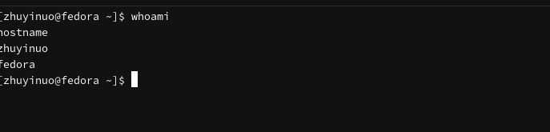

Figure 2: Имя пользователя и хоста

# 5 Установка Fedora Linux (рабочий стол)

После установки система загрузилась в штатном режиме, выполнена начальная настройка.

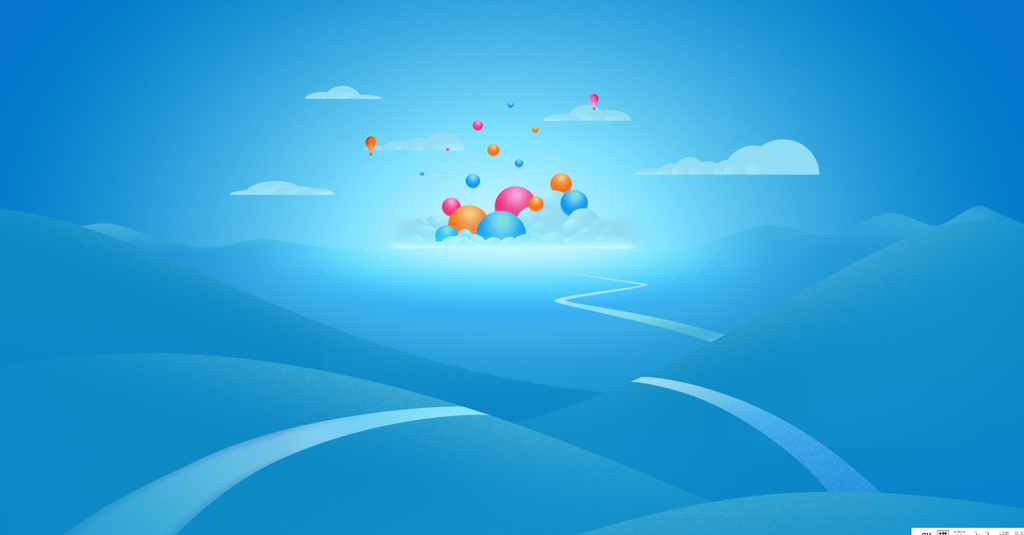

Figure 3: Установленная система Fedora

# 6 Настройка раскладки клавиатуры

Настроена раскладка клавиатуры в файле `/etc/X11/xorg.conf.d/00-keyboard.conf`. После перезагрузки раскладка работает корректно.

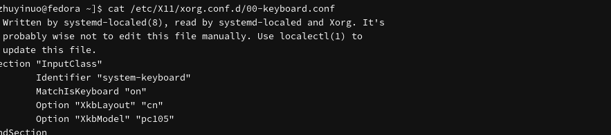

Figure 4: Настройка раскладки клавиатуры

# 7 Установка ПО для создания документации

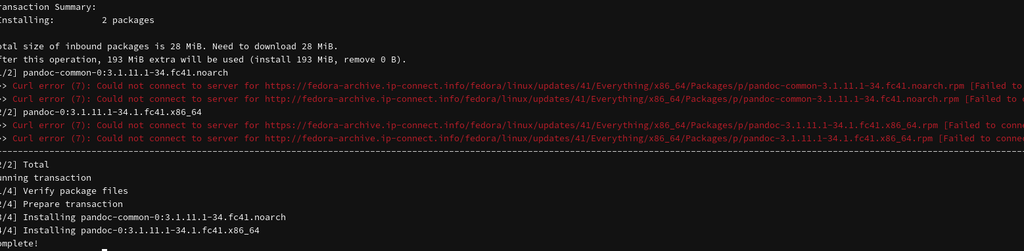

# 8 Анализ загрузки системы с помощью dmesg

Получена информация о версии ядра Linux с помощью команды `sudo dmesg | grep -i "Linux version"`.

[figure not shown]

Figure 6: Версия ядра

Получена информация о частоте процессора с помощью команды `sudo dmesg | grep -i "mhz"`.

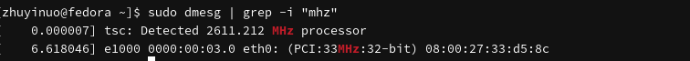

Figure 7: Частота процессора

Получена информация о модели процессора с помощью команды `sudo dmesg | grep -i "CPU0"`.

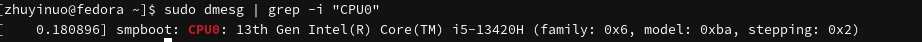

Figure 8: Модель процессора

Получена информация об объёме доступной оперативной памяти с помощью команды `sudo dmesg | grep -i "Memory"`.

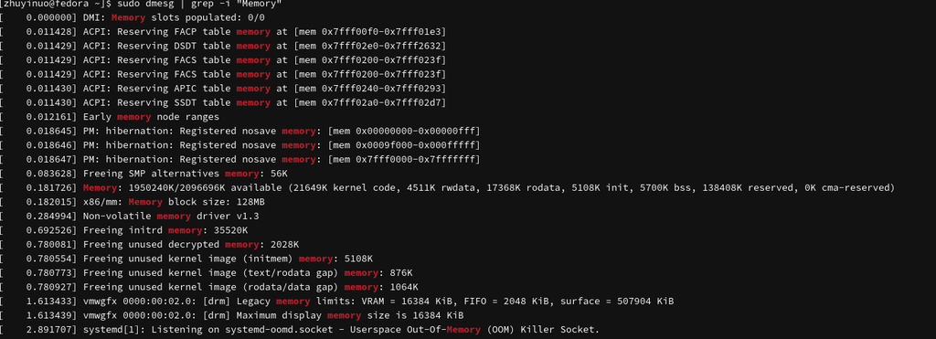

Figure 9: Объём памяти

Получена информация о типе обнаруженного гипервизора с помощью команды `sudo dmesg | grep -i "Hypervisor"`.

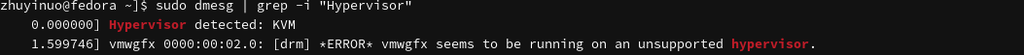

Figure 10: Тип гипервизора

Получена информация о типе файловой системы корневого раздела.

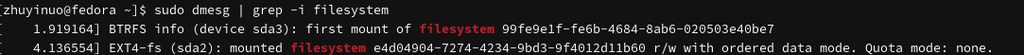

Figure 11: Тип файловой системы

Получена информация о последовательности монтирования файловых систем с помощью команды `sudo dmesg | grep -i "mount"`.

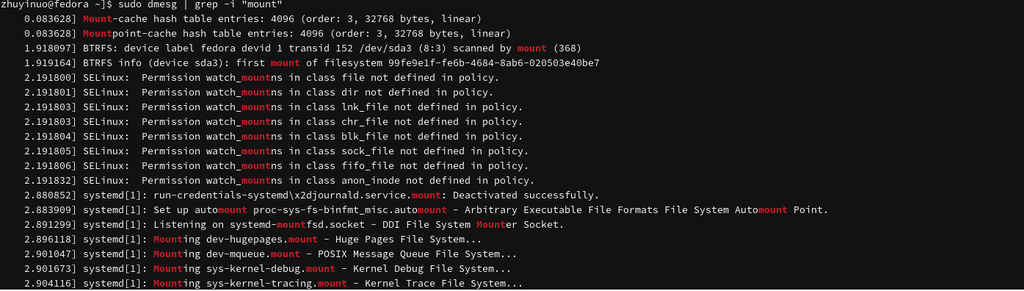

Figure 12: Монтирование файловых систем

# 9 Выводы

В ходе лабораторной работы была установлена операционная система Fedora Linux на виртуальную машину VirtualBox. Выполнены начальная настройка системы, настройка раскладки клавиатуры, установка имени пользователя и хоста, установка программного обеспечения для создания документации. С помощью команды dmesg проанализирована последовательность загрузки системы и получена информация о версии ядра, процессоре, оперативной памяти, гипервизоре и файловых системах.

# 10 Контрольные вопросы

**1. Какую информацию содержит учётная запись пользователя?**

Имя пользователя, пароль, UID, GID, комментарий, домашний каталог, командная оболочка.

**2. Укажите команды терминала и приведите примеры:**

- для получения справки по команде: `man command`, `command --help`
- для перемещения по файловой системе: `cd /home/user`
- для просмотра содержимого каталога: `ls -la`
- для определения объёма каталога: `du -sh /home/user`
- для создания / удаления каталогов / файлов: `mkdir dir`, `rmdir dir`, `touch file`, `rm file`
- для задания определённых прав на файл / каталог: `chmod 755 file`, `chown user file`
- для просмотра истории команд: `history`

**3. Что такое файловая система? Приведите примеры с краткой характеристикой.**

Файловая система — способ организации и хранения файлов на носителе. Примеры: ext4 (журналируемая, стандартная для Linux), XFS (высокопроизводительная), Btrfs (поддержка снапшотов и сжатия), NTFS (Windows), FAT32 (совместимость).

**4. Как посмотреть, какие файловые системы подмонтированы в ОС?**

`df -h`, `mount`, `cat /proc/mounts`

**5. Как удалить зависший процесс?**

`kill -9 <PID>`, `pkill -9 <имя>`, `killall -9 <имя>`

# 11 Список литературы

1. Робачевский А., Немнюгин С., Стесик О. Операционная система UNIX. — 2-е изд. — БХВ-Петербург, 2010.
2. Колисниченко Д. Н. Самоучитель системного администратора Linux. — СПб. : БХВ-Петербург, 2011. — (Системный администратор).
3. Таненбаум Э., Бос Х. Современные операционные системы. — 4-е изд. — СПб. : Питер, 2015. — (Классика Computer Science).
4. Neil N. J. Learning CentOS: A Beginners Guide to Learning Linux. — CreateSpace Independent Publishing Platform, 2016.
5. Unix и Linux: руководство системного администратора / Э. Немет, Г. Снайдер, Т. Хейн, Б. Уэйли, Д. Макни. — 5-е изд. — СПб. : ООО «Диалектика», 2020.